# Analyzing Aggregated Readings

Channels provide data at the instrumentation-level, however it is possible to analyze aggregate readings at the subsystem level.

This tutorial walks through analyzing aggregate/total instantaneous readings for channels in the Electrical subsystem

## Get the data you need

First, we can use the download link from the Data page to import the data for the Electrical Subsystem:

```r
# load libraries
library(ggplot2) # plotting library
library(reshape2) # library for reshaping data easily

# get data
elec <- read.csv("https://s3.amazonaws.com/net-zero/2015-data-files/Elec.csv", header=TRUE, na.strings=c("NA", "NULL", "", " "))

#exclude this from tutorial:
load("~/backup.Rda")
elec <- backup
```

There are 545 channels in the Electrical subsystem, however a subset of those channels measure total electrical readings, which is what we are interested in.

```r
# Row and column count for Electrical channel data
dim(elec)
```

```
## [1] 524161    545
```

```r
# List of channels that contain total readings
totals <- names(elec)[grep("Elec_Total", names(elec))]
totals
```

```
##  [1] "Elec_TotalApplianceEnergy"
##  [2] "Elec_TotalAppliancePower"
##  [3] "Elec_TotalDHWEnergy"
##  [4] "Elec_TotalDHWPower"
##  [5] "Elec_TotalGenerationEnergy"
##  [6] "Elec_TotalGenerationPower"
##  [7] "Elec_TotalHVACEnergy"
##  [8] "Elec_TotalHVACPower"
##  [9] "Elec_TotalLightingEnergy"
## [10] "Elec_TotalLightingPower"
## [11] "Elec_TotalNZERTFEnergyExportCT"
## [12] "Elec_TotalNZERTFEnergyExportSumCirc"
## [13] "Elec_TotalNZERTFEnergyImportCT"
## [14] "Elec_TotalNZERTFEnergyImportSumCirc"
## [15] "Elec_TotalNZERTFEnergyLoadSumCirc"
## [16] "Elec_TotalNZERTFPowerExportCT"
## [17] "Elec_TotalNZERTFPowerExportSumCirc"
## [18] "Elec_TotalNZERTFPowerImportCT"
## [19] "Elec_TotalNZERTFPowerImportSumCirc"
## [20] "Elec_TotalNZERTFPowerLoadSumCirc"
## [21] "Elec_TotalOccupantEnergy"
## [22] "Elec_TotalOccupantPower"
## [23] "Elec_TotalPlugLoadEnergy"
## [24] "Elec_TotalPlugLoadPower"
```

## Working with the data

Now that we know which variables contain total readings from this subsystem we can take a closer look.

```r
# subset data to Totals only and any timestamp variables we need
elec <- elec[,c("Timestamp", "TimeStamp_Count", "DayOfWeek", totals)]

# converts Timestamp variable into date/time format (POSIXlt)
elec$Timestamp <- strptime(elec$Timestamp, "%Y-%m-%d %H:%M:%S", tz = "EST")
```

Then decide which timestamps you are interested in. Remember that we have a reading for each minute of the year, so for this tutorial we are going to pull readings from 12pm EST on the first of each month:

```r
# extract readings from the first of each month at noon
data <- elec[elec$Timestamp %in% (elec$Timestamp[elec$Timestamp$mday == 01 & elec$Timestamp$hour == 12 & elec$Timestamp$min == 00 & elec$Timestamp$sec == 00]),]
data$TimeStamp_Count <- as.factor(1:nrow(data))
data$Timestamp <- NULL
data$DayOfWeek <- NULL
data <- melt(data, value.name = "channel")
```

Now let’s take a look at how these readings compare:

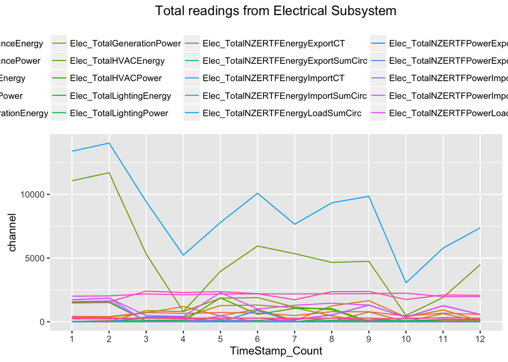

```r
ggplot(data, aes(x = TimeStamp_Count, y = channel, group = variable, colour = variable)) +
  geom_line() +
  ggtitle("Total readings from Electrical Subsystem") +
  theme(legend.position="top")
```

Once you know which readings you are most interested in, you can filter for those:

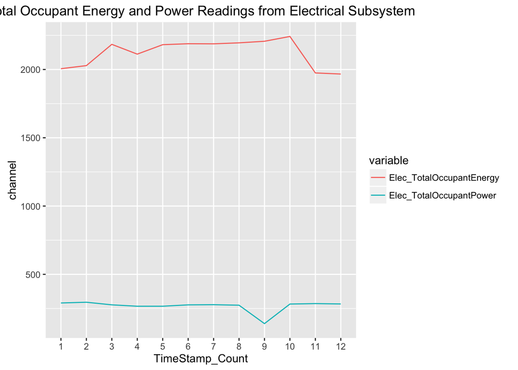

```r
ggplot(data[data$variable %in% c("Elec_TotalOccupantEnergy", "Elec_TotalOccupantPower"),], aes(x = TimeStamp_Count, y = channel, group = variable, colour = variable)) +
  geom_line() +
  ggtitle("Total Occupant Energy and Power Readings from Electrical Subsystem")
```